# Chapter 07: Compound Types and References

ENG3091

Author

Affiliation

Khiem Nguyen

University of Glasgow

# 1 Compound types

## 1.1 Types built from other types

Imagine a program that keeps track of employees:

```cpp
int id1{42};
int id2{24};
int id3{162};

double salary1{42123.3};
double salary2{43784.5};
double salary3{39469.2};
// ...names, roles, job titles, and so on
```

With 100 employees, this simply doesn’t scale. We need types that are **built from other types**: **compound types** (also called *composite types*).

## 1.2 The compound types of C++

**Built into the language**

- functions (Chapter 02)
- references (**today**)
- pointers (Chapter 08)
- C-style arrays

**Defined by you, the programmer**

- enumerations (`enum`, `enum class`)
- structs (`struct`)
- classes (`class`): the heart of this course, from Chapter 10
- unions (`union`)

We won’t cover all of them: there isn’t time. You’ll see that structs and classes are very similar, so studying one carefully is enough.

Even a function has a compound type: the type of `void do_something(int x, double y)` is `void(int, double)`.

# 2 Value categories: lvalues and rvalues

## 2.1 Two properties of every expression

Recall: an **expression** combines literals, variables, operators and function calls to produce a value. Every expression has:

- a **type**: the type of the value it produces;

  ```cpp
  auto v1{12 / 4};   // int / int gives int
  auto v2{12.0 / 4}; // double / int gives double
  ```

- a **value category**: what *kind* of thing it produces, an object or just a value.

The type tells the compiler whether an expression makes sense in a given place: `print("foo")` won’t compile if `print` expects an `int`. The value category does the same job in a different way. Before references can make sense, we need value categories.

## 2.2 Why is `x = 5` fine, but `5 = x` isn’t?

```
lvalue_assignment.cpp
```

```cpp
int main() {
    int x{};
    x = 5; // fine: x is a variable we can assign to
    5 = x; // error: you can't assign to 5
    return 0;
}
```

```
error: lvalue required as left operand of assignment
```

As humans, we can see that `5 = x` makes no sense. But how does the compiler know which expressions may go on the left of `=`?

The answer is in the error message: the left side must be an **lvalue**.

## 2.3 lvalues and rvalues

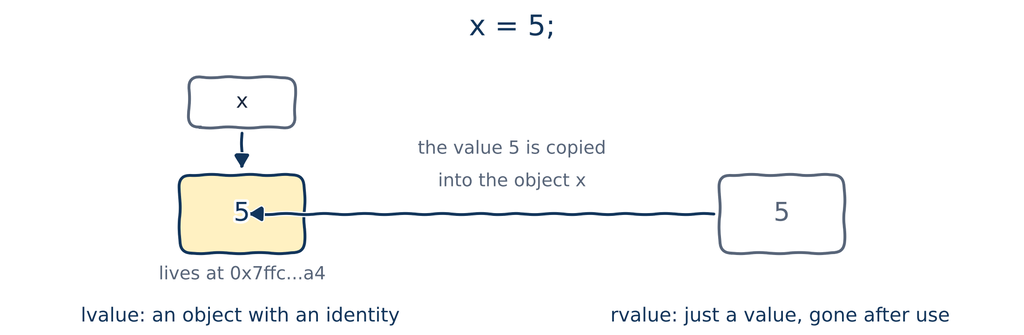

- An **lvalue** evaluates to an **identifiable object** (or function): something with a name or an address, which outlives the expression. Example: a variable `x`.
- An **rvalue** evaluates to a **value**: a literal, a temporary result, something returned by value. It’s gone at the end of the expression.

Since C++11 there are also *glvalues*, *prvalues* and *xvalues*, for a feature called *move semantics*. Lvalues and rvalues are enough for us.

## 2.4 Spot the rvalues

```
rvalue_expression_example.cpp
```

```cpp
int return5() { return 5; }

int main() {
    int x{5};            // 5 is an rvalue
    const double d{1.2}; // 1.2 is an rvalue

    int y{x};                   // x is a modifiable lvalue
    const double e{d};          // d is a non-modifiable lvalue
    int z{return5()};           // return5() is an rvalue (returned by value)
    int w{x + 1};               // x + 1 is an rvalue
    int q{static_cast<int>(d)}; // the converted value is an rvalue
    return y + z + w + q + static_cast<int>(e);
}
```

- `return5()`, `x + 1` and `static_cast<int>(d)` produce temporary values, not identifiable objects: they’re rvalues.
- `static_cast<int>(d)` is an **explicit conversion**: it turns the `double` `1.2` into the `int` `1`.
- One surprise: a string literal like `"Hello"` is an lvalue. (It’s stored somewhere in memory for the whole program.)

## 2.5 lvalue-to-rvalue conversion

Operators expect rvalues as operands, unless stated otherwise. But this compiles:

```cpp
int x{1};
int y{2};
x = y;     // y is an lvalue, not an rvalue!
x = x + 1; // x appears on both sides
```

- Where an rvalue is expected and an lvalue is given, the lvalue goes through an **lvalue-to-rvalue conversion**: it’s simply evaluated to produce its value. In `x = y`, `y` becomes the value `2`.
- In `x = x + 1`, the left `x` is an lvalue (the object we assign to). The right `x` is converted to its value, say `42`, and `x + 1` produces the rvalue `43`.

**ImportantKey idea**

An lvalue can be used wherever an rvalue is expected. An rvalue can never be used where an lvalue is required.

## 2.6 A tool to tell them apart

```
tell_value_categories.cpp
```

```cpp
#include "value_category.h" // our little tool
#include <string>

int get_int() { return 5; }

int main() {
    int x{5};
    PRINT_VALUE_CATEGORY(5);
    PRINT_VALUE_CATEGORY(get_int());
    PRINT_VALUE_CATEGORY(x);
    PRINT_VALUE_CATEGORY(x + 1);
    PRINT_VALUE_CATEGORY(std::string{"Hello"});
    PRINT_VALUE_CATEGORY("Hello");
    PRINT_VALUE_CATEGORY(++x);
    PRINT_VALUE_CATEGORY(x++);
    return 0;
}
```

```
5 is an rvalue
get_int() is an rvalue
x is an lvalue
x + 1 is an rvalue
std::string{"Hello"} is an rvalue
"Hello" is an lvalue
++x is an lvalue
x++ is an rvalue
```

The tool lives in `value_category.h`. Don’t worry about how it works.

# 3 lvalue references

## 3.1 A reference is another name for an object

A **reference** is an **alias**: a second name for an object that already exists.

- Anything you do to the reference happens to the object it refers to.
- References may seem pointless at first. They’re used *everywhere* in C++, as you’ll see shortly.

```cpp
int        // an int
int&       // an lvalue reference to an int
double&    // an lvalue reference to a double
const int& // an lvalue reference to a const int
```

- `int&` (one ampersand) is an **lvalue reference**. There are also *rvalue references*, `int&&`, with two ampersands. They came with C++11, and many experienced programmers have never needed them.
- Since lvalue references are by far the most common, “reference” on its own means *lvalue reference*.

## 3.2 Your first reference

```
lvalue_reference_variables.cpp
```

```cpp
#include <iostream>

int main() {
    int x{5};    // an ordinary int variable
    int& ref{x}; // ref is a reference to x: another name for x

    std::cout << x << '\n';   // prints 5
    std::cout << ref << '\n'; // prints 5, through ref
    return 0;
}
```

```
5
5
```

[figure not shown]

## 3.3 Changing an object through a reference

```
modify_value_through_nonconst_reference.cpp
```

```cpp
#include <iostream>

int main() {
    int x{42};
    int& ref{x}; // ref is another name for x

    std::cout << x << ' ' << ref << '\n';

    x = 24; // change x...
    std::cout << x << ' ' << ref << '\n';

    ref = 12; // ...or change it through ref
    std::cout << x << ' ' << ref << '\n';
    return 0;
}
```

What will this print? Think first!

```
42 42
24 24
12 12
```

**TipBest practice**

Write the ampersand next to the type, `int& ref`, not next to the name. It’s part of the type.

## 3.4 A reference must be initialized

```
reference_must_be_initialized.cpp
```

```cpp
int main() {
    int& invalid_ref; // error: a reference must be initialized

    int x{5};
    int& ref{x}; // fine: ref is bound to x
    return 0;
}
```

```
error: 'invalid_ref' declared as reference but not initialized
```

- Initializing a reference **binds** it to an object; the object is called its **referent**.
- Don’t worry: I won’t test your memory of these terms in the paper exam!

## 3.5 Which objects can a reference bind to?

```
nonconst_reference_binding.cpp
```

```cpp
int main() {
    int x{5};
    int& ref{x}; // fine: x is a modifiable lvalue

    const int y{5};
    int& invalid_ref{y}; // error: y is const

    int& invalid_ref2{0}; // error: 0 is an rvalue
    return 0;
}
```

```
error: binding reference of type 'int&' to 'const int' discards qualifiers
error: cannot bind non-const lvalue reference of type 'int&' to an rvalue of type 'int'
```

Why not? A non-const reference lets you **change** its referent. Binding one to a `const` object, or to a temporary value like `0`, would let you change something that must not, or cannot, change.

## 3.6 A reference can’t be reseated

```
reference_cannot_be_reseated.cpp
```

```cpp
#include <iostream>

int main() {
    int x{5};
    int y{6};

    int& ref{x}; // ref is another name for x

    ref = y; // does this make ref refer to y?

    std::cout << x << '\n'; // what does this print?
    return 0;
}
```

```
6
```

`ref = y` does **not** make `ref` refer to `y`. `ref` *is* `x`, so this is simply `x = y`. Once bound, a reference stays bound to the same object for its whole life.

**NoteComing from Python**

A Python name can be rebound to a different object at any time: `a = b` does exactly that. A C++ reference never can be.

## 3.7 Lifetimes and dangling references

```
lifetime_reference_and_referent.cpp
```

```cpp
#include <iostream>

int main() {
    int x{42};

    {                             // a nested block
        int& ref{x};              // ref is a reference to x
        std::cout << ref << '\n'; // prints 42
    } // ref is destroyed here; x doesn't notice

    std::cout << x << '\n'; // still prints 42
    return 0;
} // x is destroyed here
```

```
42
42
```

- A reference and its referent have **independent lifetimes**. Destroying the reference doesn’t affect the object.
- The other way round is dangerous: if the **object** is destroyed first, the reference is left **dangling**. Using a dangling reference is undefined behaviour.

## 3.8 References are not objects

- A reference is just a name. The compiler often replaces it with the referent and gives it no memory at all (though sometimes it does need some).
- So “reference variable” is a slight misnomer: variables are named *objects*.
- One consequence: you can’t have a reference to a reference.

So far references look like a curiosity. Their real job is coming up next.

# 4 Pass by reference

## 4.1 Pass by value can be expensive

In Chapter 02 we learned **pass by value**: the argument is **copied** into the parameter. Copying a `double` is cheap; copying a long `std::string` is not:

```
pass_by_value_string.cpp
```

```cpp
#include <iostream>
#include <string>

void print_value(std::string y) { // y is a copy of x
    std::cout << y << '\n';
} // the copy is destroyed here

int main() {
    std::string x{"My name is Khiem. What's your name?"};
    print_value(x); // copies every character of x: expensive!
    return 0;
}
```

The copy is made, used once, and thrown away. A waste! Most standard library types, like `std::string`, are expensive to copy.

## 4.2 Pass by reference

Make the parameter a **reference**, and it is simply bound to the argument. No copy is made:

```
pass_by_reference.cpp
```

```cpp
#include <iostream>
#include <string>

void print_value(std::string& y) { // y is a reference: no copy
    std::cout << y << '\n';
}

int main() {
    std::string x{"Hello, world!"};
    print_value(x); // y is bound to x: cheap
    return 0;
}
```

```
Hello, world!
```

## 4.3 Value versus reference, in a picture

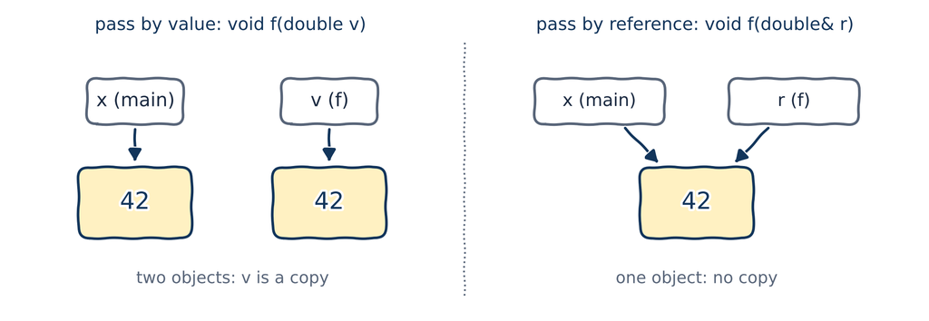

- **Pass by value:** the parameter is a new object, initialized with a copy of the argument.
- **Pass by reference:** the parameter is just another name for the argument. Nothing is copied, and the function works on the caller’s object itself.

## 4.4 Don’t believe me? Check the addresses

```
pass_by_value_vs_pass_by_reference.cpp
```

```cpp
#include <iostream>

void print_addresses(double val, double& ref) {
    std::cout << "address of val (a copy):  " << &val << '\n';
    std::cout << "address of ref (no copy): " << &ref << '\n';
}

int main() {
    double x{42.0};
    std::cout << "address of x:             " << &x << '\n';
    print_addresses(x, x);
    return 0;
}
```

```
address of x:             0x7ffcc2285eb0
address of val (a copy):  0x7ffcc2285e98
address of ref (no copy): 0x7ffcc2285eb0
```

`ref` has the **same address** as `x`: it is `x`. `val` lives somewhere else. (`&x` gives the address of `x`, more in Chapter 08. Your addresses will differ.)

## 4.5 Changing the caller’s variable

```
pass_by_reference_change_value.cpp
```

```cpp
#include <iostream>

void add_value(double& y, double v) { // y is bound to the caller's x
    y += v;                           // so this changes x itself
}

int main() {
    double x{42.0};
    std::cout << "x = " << x << '\n';
    add_value(x, 24.0);
    std::cout << "x = " << x << '\n';
    return 0;
}
```

```
x = 42
x = 66
```

Any change made through a non-const reference parameter changes the caller’s argument itself. That’s useful when a function’s whole purpose is to modify something.

## 4.6 The swap that finally swaps

```
swap_by_reference.cpp
```

```cpp
#include <iostream>

void swap_values(int& x, int& y) { // no copies
    int temp{x};
    x = y;
    y = temp;
}

int main() {
    int x{100};
    int y{200};
    swap_values(x, y);
    std::cout << "x = " << x << ", y = " << y << '\n';
    return 0;
}
```

```
x = 200, y = 100
```

Remember the swap that didn’t swap in Chapter 02? With references, it finally works.

## 4.7 Non-const reference parameters are picky

```
pass_by_reference_accept_modifiable_lvalues.cpp
```

```cpp
#include <iostream>

void print_value(int& y) { // only accepts modifiable lvalues
    std::cout << y << '\n';
}

int main() {
    int x{5};
    print_value(x); // fine: x is a modifiable lvalue

    const int z{5};
    print_value(z); // error: z is const
    print_value(5); // error: 5 is an rvalue
    return 0;
}
```

```
error: binding reference of type 'int&' to 'const int' discards qualifiers
error: cannot bind non-const lvalue reference of type 'int&' to an rvalue of type 'int'
```

A non-const reference parameter only accepts **modifiable lvalues**: in practice, non-const variables. But often we just want to *read* an expensive argument without copying it, whatever it is.

## 4.8 Pass by const reference

```
pass_by_const_reference.cpp
```

```cpp
#include <iostream>

void print_value(const int& y) { // a const reference
    std::cout << y << '\n';
}

int main() {
    int x{5};
    print_value(x); // fine: a modifiable lvalue

    const int z{6};
    print_value(z); // fine: a const lvalue

    print_value(7); // fine: an rvalue (bound to a temporary)
    return 0;
}
```

```
5
6
7
```

A **const reference** binds to anything: modifiable lvalues, const lvalues and rvalues. That’s exactly why C++ allows const references to bind to rvalues. Without it, you couldn’t pass a literal like `7` to a function taking a reference.

## 4.9 A const reference can’t change its referent

```
const_reference_cannot_modify.cpp
```

```cpp
void add_value(const double& ref, double value) {
    ref = ref + value; // error: we promised not to change ref
}

int main() {
    double x{1.0};
    add_value(x, 2.0);
    return 0;
}
```

```
error: assignment of read-only reference 'ref'
```

No copy **and** no accidental changes: we’re greedy, and with const references we get both.

## 4.10 Value, reference or const reference?

**TipBest practice**

- **Fundamental types** (`int`, `double`, `char`, `bool`): pass by **value**. They’re cheap to copy.
- **Class types** (`std::string`, `std::vector`, your own classes later): pass by **const reference**, so there’s no copy.
- Pass by **non-const reference** only when the function is meant to change the argument.

For read-only text, C++17 also offers `std::string_view`, a cheap view of a string. Strings are the case Chapter 04 promised we’d come back to.

# 5 Return by reference

## 5.1 Return by reference

Returning by value **copies** the result back to the caller. Returning a **reference** avoids that copy:

```
return_by_ref_academic.cpp
```

```cpp
#include <iostream>
#include <string>

const std::string& get_program_name() { // returns a const reference
    // static: created once, lives until the program ends
    static const std::string program_name{"Calculator"};
    return program_name;
}

int main() {
    std::cout << "This program is named " << get_program_name() << '\n';
    return 0;
}
```

```
This program is named Calculator
```

A **static** local variable is created once and lives until the program ends, unlike an ordinary local variable. Here that’s essential, as the next slide shows.

## 5.2 The object must outlive the function

```
return_by_ref_lifetime.cpp
```

```cpp
#include <iostream>
#include <string>

const std::string& get_program_name() {
    // not static: destroyed when the function returns
    const std::string program_name{"Calculator"};
    return program_name; // returns a reference to a dying object
}

int main() {
    std::cout << "This program is named " << get_program_name() << '\n';
    return 0;
}
```

```
$ g++ -std=c++20 -Wall return_by_ref_lifetime.cpp
warning: reference to local variable 'program_name' returned
$ ./a.out
Segmentation fault
```

`program_name` is destroyed when the function returns, so the caller receives a **dangling reference**: undefined behaviour. On my machine, it crashed.

## 5.3 A use for return by reference

```
return_by_ref_larger.cpp
```

```cpp
#include <iostream>

int& larger(int& a, int& b) { // returns a reference to a or to b
    return (a > b) ? a : b;
}

int main() {
    int x{5};
    int y{8};

    larger(x, y) = 0; // resets whichever is larger: here, y
    std::cout << "x = " << x << ", y = " << y << '\n';
    return 0;
}
```

```
x = 5, y = 0
```

`larger()` returns a reference to the caller’s own variable, so the call can even appear on the **left** of `=`: it’s an lvalue! This is safe because `x` and `y` outlive the call.

# 6 Wrapping up

## 6.1 Summary

- Every expression has a **type** and a **value category**. An **lvalue** is an identifiable object; an **rvalue** is just a value.
- A **reference** (`int& ref{x};`) is another name for an existing object. It must be initialized and can’t be reseated.
- A non-const reference binds only to modifiable lvalues; a **const reference** binds to anything.
- **Pass by reference** avoids copies and lets a function change its argument. **Pass by const reference** avoids copies without allowing changes.
- Pass fundamental types by value, class types by const reference.
- Never return (or keep) a reference to an object that is about to be destroyed: **dangling references** are undefined behaviour.

## 6.2 Keep learning

Explore these on your own, with Google Gemini in Guided Learning mode or on learncpp.com:

1. [Value categories (lvalues and rvalues)](https://www.learncpp.com/cpp-tutorial/value-categories-lvalues-and-rvalues/)
2. [Pass by const lvalue reference](https://www.learncpp.com/cpp-tutorial/pass-by-const-lvalue-reference/), and when to pass by value instead
3. [`std::string_view`](https://www.learncpp.com/cpp-tutorial/introduction-to-stdstring_view/)
4. [Static local variables](https://www.learncpp.com/cpp-tutorial/static-local-variables/)

**Next up, Chapter 08:** pointers, the other way to refer to an object.